# AQI

*Phase - 1 : Importing the csv file into R studio*

```r
getwd()
```

```
[1] "E:/College Education/DA-IICT/Study/Sem 1/Pratik - Projects/R Project/Indian_Air_Pollution_Data"
```

```r
AQI_data = read.csv('AQIdatasetmain.csv')
```

**getwd() :** – To get or set Working directory.  
**read.csv() :** – To read the comma seperated value files.

*Phase - 2 : To see the content what data holds*

```r
head(AQI_data)
```

|  | StationId | City | PM2.5 | PM10 | NO | NO2 | NOx | NH3 | CO | SO2 | O3 | Benzene | Toluene | Xylene | AQI | AQI_Bucket |
| --- | --- | --- | --- | --- | --- | --- | --- | --- | --- | --- | --- | --- | --- | --- | --- | --- |
| 1 | Andhra_Pradesh | Amaravati | 71.36 | 115.75 | 1.75 | 20.65 | 12.40 | 12.19 | 0.10 | 10.76 | 109.26 | 0.17 | 5.92 | 0.10 | 132 | Moderate |
| 2 | Andhra_Pradesh | Amaravati | 81.40 | 124.50 | 1.44 | 20.50 | 12.08 | 10.72 | 0.12 | 15.24 | 127.09 | 0.20 | 6.50 | 0.06 | 184 | Moderate |
| 3 | Andhra_Pradesh | Amaravati | 78.32 | 129.06 | 1.26 | 26.00 | 14.85 | 10.28 | 0.14 | 26.96 | 117.44 | 0.22 | 7.95 | 0.08 | 197 | Moderate |
| 4 | Andhra_Pradesh | Amaravati | 73.96 | 113.56 | 4.58 | 19.29 | 13.97 | 10.95 | 0.10 | 13.90 | 123.80 | 0.17 | 2.85 | 0.04 | 191 | Moderate |
| 5 | Andhra_Pradesh | Amaravati | 89.90 | 140.20 | 7.71 | 26.19 | 19.87 | 13.12 | 0.10 | 19.37 | 128.73 | 0.25 | 2.79 | 0.07 | 191 | Moderate |
| 6 | Andhra_Pradesh | Amaravati | 87.14 | 130.52 | 0.97 | 21.31 | 12.12 | 14.36 | 0.15 | 11.41 | 114.80 | 0.23 | 3.82 | 0.04 | 227 | Poor |

**Shapiro Test:**

```r
apply(AQI_data[,c(3:14)],2,shapiro.test)
```

```
$PM2.5

    Shapiro-Wilk normality test

data:  newX[, i]
W = 0.72028, p-value = 1.398e-11


$PM10

    Shapiro-Wilk normality test

data:  newX[, i]
W = 0.88156, p-value = 9.438e-07


$NO

    Shapiro-Wilk normality test

data:  newX[, i]
W = 0.7365, p-value = 3.39e-11


$NO2

    Shapiro-Wilk normality test

data:  newX[, i]
W = 0.92744, p-value = 0.0001137


$NOx

    Shapiro-Wilk normality test

data:  newX[, i]
W = 0.77378, p-value = 3.015e-10


```

[output cut: 39 more lines]

```

$Toluene

    Shapiro-Wilk normality test

data:  newX[, i]
W = 0.74148, p-value = 4.482e-11


$Xylene

    Shapiro-Wilk normality test

data:  newX[, i]
W = 0.83072, p-value = 1.418e-08
```

P-value is < alpha(0.05), so we can say that the data is not normal.

**head(data) :** – Return the first parts of the matrix,table or dataframe

**Phase - 3 : To know the summary of data(mean,median,mode,Quantile)**

```r
# Moderate , Poor , Satisfactory, Very Poor, Severe,  Good
summary(AQI_data)
```

```
  StationId             City               PM2.5             PM10
 Length:87          Length:87          Min.   : 11.04   Min.   : 18.03
 Class :character   Class :character   1st Qu.: 26.41   1st Qu.: 70.61
 Mode  :character   Mode  :character   Median : 64.01   Median :107.73
                                       Mean   : 73.51   Mean   :126.63
                                       3rd Qu.: 90.66   3rd Qu.:179.50
                                       Max.   :412.34   Max.   :404.52
       NO              NO2             NOx              NH3
 Min.   : 0.570   Min.   : 3.13   Min.   :  2.18   Min.   : 2.77
 1st Qu.: 3.615   1st Qu.:12.73   1st Qu.: 14.29   1st Qu.:12.12
 Median : 7.250   Median :19.87   Median : 18.21   Median :14.36
 Mean   :13.867   Mean   :24.25   Mean   : 28.75   Mean   :17.51
 3rd Qu.:15.985   3rd Qu.:32.09   3rd Qu.: 34.78   3rd Qu.:22.60
 Max.   :78.090   Max.   :66.23   Max.   :112.44   Max.   :41.78
       CO              SO2               O3            Benzene
 Min.   : 0.100   Min.   : 3.390   Min.   :  1.31   Min.   : 0.010
 1st Qu.: 0.575   1st Qu.: 9.315   1st Qu.: 18.39   1st Qu.: 0.580
 Median : 0.850   Median :12.500   Median : 26.34   Median : 2.940
 Mean   : 1.785   Mean   :15.611   Mean   : 33.49   Mean   : 3.871
 3rd Qu.: 1.130   3rd Qu.:18.995   3rd Qu.: 36.52   3rd Qu.: 6.270
 Max.   :27.140   Max.   :79.470   Max.   :128.73   Max.   :12.450
    Toluene           Xylene            AQI         AQI_Bucket
 Min.   : 0.040   Min.   : 0.000   Min.   : 28.0   Length:87
 1st Qu.: 1.520   1st Qu.: 0.575   1st Qu.: 95.0   Class :character
 Median : 2.850   Median : 5.060   Median :136.0   Mode  :character
 Mean   : 6.290   Mean   : 6.136   Mean   :178.6
 3rd Qu.: 9.975   3rd Qu.: 7.680   3rd Qu.:227.0
 Max.   :41.200   Max.   :25.660   Max.   :653.0
```

[figure not shown]

```r
#Moderate,Very Poor,Poor , Severe , Good, Satisfactory
#Average = mean(AQI_data$AQI)
moderate = length(which(AQI_data$AQI_Bucket == 'Moderate'))
VeryPoor = length(which(AQI_data$AQI_Bucket == 'Very_Poor'))
Poor = length(which(AQI_data$AQI_Bucket == 'Poor'))
Severe = length(which(AQI_data$AQI_Bucket == 'Severe'))
Satisfactory = length(which(AQI_data$AQI_Bucket == 'Satisfactory'))
Good = length(which(AQI_data$AQI_Bucket == 'Good'))
pie_chart = cbind(Severe,VeryPoor,Poor,Average,moderate,Satisfactory,Good)
percentage = round(100*pie_chart/sum(pie_chart),)
pie(pie_chart,labels = percentage,col = rainbow(length(pie_chart)),main = "AQI Status",radius = 1)

legend("topright",c("Severe","Very_Poor","Poor","Moderate","Satisfactory","Good"),cex = 0.5,fill = rainbow(length(pie_chart)))
```

*Phase - 5 : Correlation between different affecting AQI*

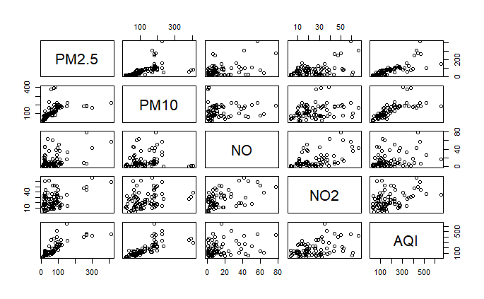

```r
pairs(AQI_data[,c(3:6,15)])
```

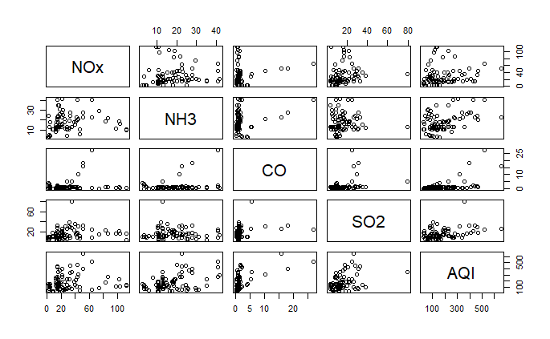

```r
pairs(AQI_data[,c(7:10,15)])
```

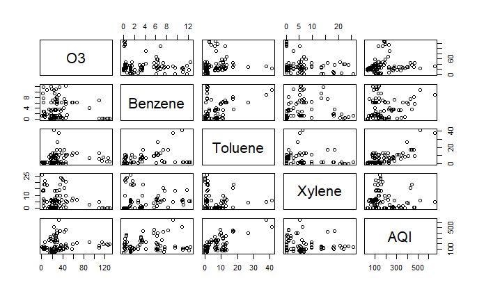

```r
pairs(AQI_data[,c(11:15)])
```

*Phase - 6 : Testing of Hypothesis*

Correlation

H0 : Correlation between Xylene and AQI is zero. H1 : Correlation between Xylene and AQI is not zero.

```r
cor.test(AQI_data$Xylene,AQI_data$AQI)
```

```
    Pearson's product-moment correlation

data:  AQI_data$Xylene and AQI_data$AQI
t = -0.81602, df = 85, p-value = 0.4168
alternative hypothesis: true correlation is not equal to 0
95 percent confidence interval:
 -0.2933652  0.1248007
sample estimates:
        cor
-0.08816532
```

H0 : Correlation between PM2.5 and AQI is zero. H1 : Correlation between PM2.5 and AQI is not zero.

```r
cor.test(AQI_data$PM2.5,AQI_data$AQI)
```

```
    Pearson's product-moment correlation

data:  AQI_data$PM2.5 and AQI_data$AQI
t = 11.307, df = 85, p-value < 2.2e-16
alternative hypothesis: true correlation is not equal to 0
95 percent confidence interval:
 0.6744753 0.8473296
sample estimates:
      cor
0.7750121
```

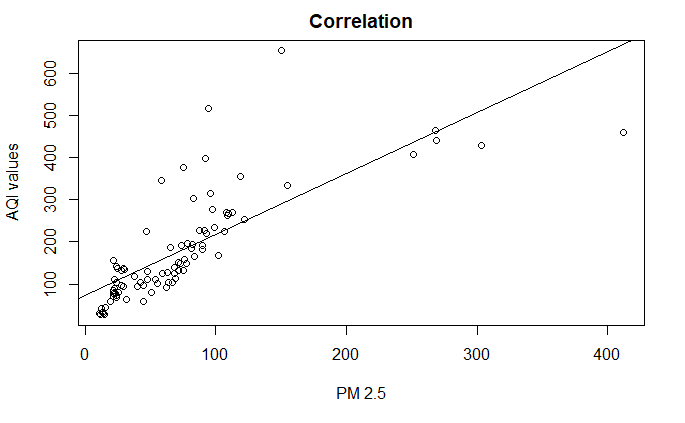

```r
plot(x = AQI_data$PM2.5, y = AQI_data$AQI,xlab ="PM 2.5",ylab = "AQI values",main = "Correlation")
abline(lm(AQI_data$AQI~AQI_data$PM2.5))
```

*Phase - 7 :*

```r
Lalu = aggregate(x = AQI_data$AQI,by = list(AQI_data$StationId),FUN = mean)
colnames(Lalu)[1] = "State"
colnames(Lalu)[2] = "AvgAQI"
print(Lalu)
```

| State | AvgAQI |
| --- | --- |
| Andhra_Pradesh | 142.25000 |
| Assam | 169.66667 |
| Bihar | 118.71429 |
| Chandigarh | 276.33333 |
| Delhi | 244.16667 |
| Gujarat | 410.83333 |
| Karnataka | 71.42857 |
| Kerala | 113.80000 |
| Madhya_Pradesh | 182.83333 |
| Maharastra | 96.16667 |

[output cut: 4 more lines]

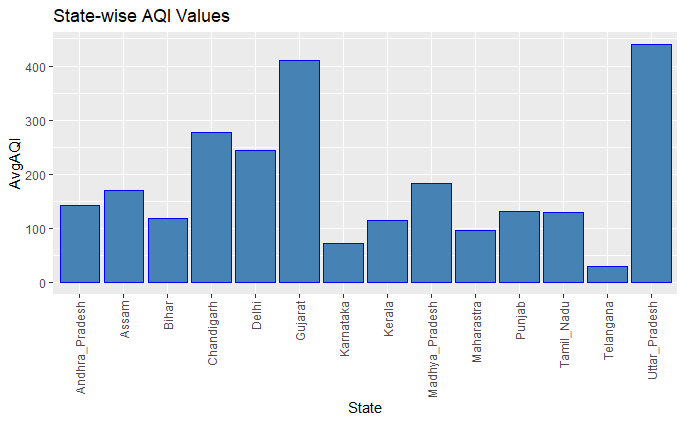

```r
require(ggplot2)
ggplot(Lalu,aes(x = State,y = AvgAQI)) + ggtitle("State-wise AQI Values") + geom_bar(stat = "identity",color ="blue", fill = "steelblue") + theme(axis.text.x = element_text(angle = 90,hjust = 1,vjust = 0.5))
```

*Phase - 8 : Regression*

Ho : There is no significant relationship between the variables H1 : There is significant relationship between the variables

Linear regression

```r
linear_rega= lm(AQI ~ CO,AQI_data)
summary(linear_rega)
```

```
Call:
lm(formula = AQI ~ CO, data = AQI_data)

Residuals:
    Min      1Q  Median      3Q     Max
-123.50  -74.59  -30.05   48.35  292.43

Coefficients:
            Estimate Std. Error t value Pr(>|t|)
(Intercept)  146.460     12.327  11.881  < 2e-16 ***
CO            18.007      2.887   6.236 1.67e-08 ***
---
Signif. codes:  0 ‘***’ 0.001 ‘**’ 0.01 ‘*’ 0.05 ‘.’ 0.1 ‘ ’ 1

Residual standard error: 104.4 on 85 degrees of freedom
Multiple R-squared:  0.3139,    Adjusted R-squared:  0.3058
F-statistic: 38.89 on 1 and 85 DF,  p-value: 1.672e-08
```

```r
linear_rega
```

```
Call:
lm(formula = AQI ~ CO, data = AQI_data)

Coefficients:
(Intercept)           CO
     146.46        18.01
```

```r
df1 = data.frame(CO = 1.69)
predict(linear_rega,df1)
```

```
       1
176.8913
```

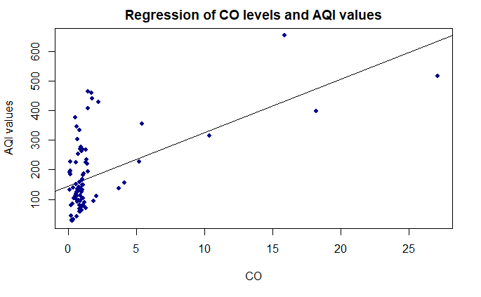

```r
plot(x = AQI_data$CO, y = AQI_data$AQI,xlab ="CO",ylab = "AQI values",main = "Regression of CO levels and AQI values",abline(linear_rega),cex = 1.3,pch=20,col="Dark Blue")
```

Multiple Regression

```r
rega = lm(AQI ~ PM2.5 + PM10 + NO + NO2 + NOx + NH3 + CO + SO2 + O3 + Benzene + Toluene + Xylene ,AQI_data)
summary(rega)
```

```
Call:
lm(formula = AQI ~ PM2.5 + PM10 + NO + NO2 + NOx + NH3 + CO +
    SO2 + O3 + Benzene + Toluene + Xylene, data = AQI_data)

Residuals:
     Min       1Q   Median       3Q      Max
-106.054  -24.209    0.804   23.109  154.998

Coefficients:
            Estimate Std. Error t value Pr(>|t|)
(Intercept) -1.85229   17.92562  -0.103   0.9180
PM2.5        0.93116    0.09160  10.166 1.08e-15 ***
PM10         0.63656    0.07584   8.394 2.33e-12 ***
NO          -0.09341    0.44768  -0.209   0.8353
NO2         -0.53375    0.42835  -1.246   0.2167
NOx          0.10776    0.26438   0.408   0.6847
NH3         -0.22906    0.66572  -0.344   0.7318
CO           9.62891    1.88765   5.101 2.52e-06 ***
SO2          0.34155    0.50460   0.677   0.5006
O3           0.18276    0.16717   1.093   0.2778
Benzene      1.25150    1.50435   0.832   0.4081
Toluene      2.21884    1.23219   1.801   0.0758 .
Xylene      -0.14488    0.69765  -0.208   0.8361
---
Signif. codes:  0 ‘***’ 0.001 ‘**’ 0.01 ‘*’ 0.05 ‘.’ 0.1 ‘ ’ 1

Residual standard error: 38.26 on 74 degrees of freedom
Multiple R-squared:  0.9199,    Adjusted R-squared:  0.9069
F-statistic: 70.78 on 12 and 74 DF,  p-value: < 2.2e-16
```

```r
xyz = data.frame(PM2.5=25.2,PM10=69,NO=28.5,NO2=37,NOx=24.3,NH3=21.3,CO=0.89,SO2=22.9,O3=108,Benzene=3.5,Toluene=6.9,Xylene=4)
predict(rega,xyz)
```

```
       1
96.10458
```

```r
cor_matrix = cor(AQI_data[,c(3:15)])
round(cor_matrix,2)
```

```
        PM2.5  PM10    NO   NO2   NOx   NH3    CO   SO2    O3 Benzene Toluene
PM2.5    1.00  0.50  0.41  0.46  0.06  0.34  0.15  0.25  0.15    0.16    0.43
PM10     0.50  1.00  0.11  0.30  0.12  0.48  0.21  0.13  0.05   -0.05    0.42
NO       0.41  0.11  1.00  0.53  0.66  0.26  0.08  0.24 -0.12    0.42    0.20
NO2      0.46  0.30  0.53  1.00  0.42  0.32  0.16  0.42  0.20    0.33    0.46
NOx      0.06  0.12  0.66  0.42  1.00  0.13  0.19  0.20 -0.11    0.41    0.13
NH3      0.34  0.48  0.26  0.32  0.13  1.00  0.29  0.02 -0.13   -0.10    0.41
CO       0.15  0.21  0.08  0.16  0.19  0.29  1.00  0.32 -0.08    0.29    0.75
SO2      0.25  0.13  0.24  0.42  0.20  0.02  0.32  1.00  0.06    0.29    0.50
O3       0.15  0.05 -0.12  0.20 -0.11 -0.13 -0.08  0.06  1.00   -0.16    0.13
Benzene  0.16 -0.05  0.42  0.33  0.41 -0.10  0.29  0.29 -0.16    1.00    0.31
Toluene  0.43  0.42  0.20  0.46  0.13  0.41  0.75  0.50  0.13    0.31    1.00
Xylene  -0.02 -0.12  0.10 -0.06  0.01 -0.18 -0.01 -0.23 -0.22    0.16   -0.14
AQI      0.78  0.73  0.28  0.42  0.15  0.45  0.56  0.35  0.11    0.21    0.73
        Xylene   AQI
PM2.5    -0.02  0.78
PM10     -0.12  0.73
NO        0.10  0.28
NO2      -0.06  0.42
NOx       0.01  0.15
NH3      -0.18  0.45
CO       -0.01  0.56
SO2      -0.23  0.35
O3       -0.22  0.11
Benzene   0.16  0.21
Toluene  -0.14  0.73
Xylene    1.00 -0.09
AQI      -0.09  1.00
```

Corplot:

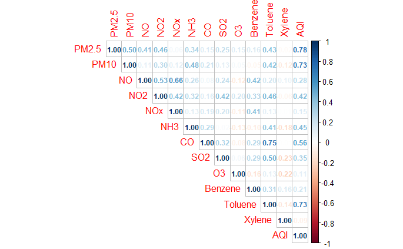

```r
require(corrplot)
corrplot(cor(AQI_data[,c(3:15)],method = "pearson"), method = 'number',type = 'upper',number.cex = 0.75, )
```

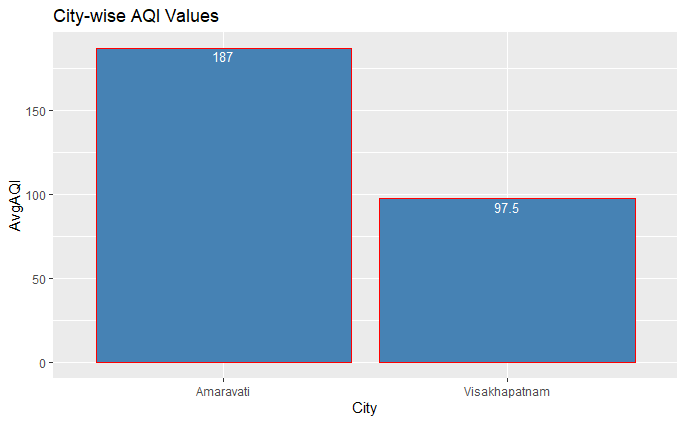

```r
Munni = aggregate(x=AQI_data$AQI,by=list(AQI_data$City),FUN = mean)
Badnam = Munni[c(2,15),]
colnames(Badnam)[1] = "City"
colnames(Badnam)[2] = "AvgAQI"
ggplot(Badnam,aes(x = City, y = AvgAQI)) + ggtitle("City-wise AQI Values") + geom_bar(stat = "identity",color ="red", fill = "steelblue") + geom_text(aes(label = AvgAQI),vjust = 1.2,color = "white", position = position_dodge(0.9),size = 3.5 )
```

```r
NA
NA
```

Chi Square:

```r
getwd()
```

```
[1] "E:/College Education/DA-IICT/Study/Sem 1/Pratik - Projects/R Project/Indian_Air_Pollution_Data"
```

```r
chi_sq = read.csv("Column_15_16.csv")
head(chi_sq)
```

|  | Toluene | AQI_Bucket |
| --- | --- | --- |
| 1 | 5.92 | 3 |
| 2 | 6.50 | 3 |
| 3 | 7.95 | 3 |
| 4 | 2.85 | 3 |
| 5 | 2.79 | 3 |
| 6 | 3.82 | 4 |

```r
# Chi-Square test:
data1 = data.matrix(chi_sq)
chisq.test(data1)
```

```
    Pearson's Chi-squared test

data:  data1
X-squared = 146.95, df = 86, p-value = 4.708e-05
```